# Contract Logistics Project

```r
# Loads the libraries to perform functions
library(tidyverse)
library(stringr)
library(plotly)
set.seed(123)
```

*DISCLAIMER: All relationships and distributions are synthetically generated but calibrated to reflect* *realistic contract logistics operations.*

# Step 0. Business context - What is this project doing?

In contract logistics, organisations often rely on multiple external carriers to transport goods across different regions and distances. Selecting the right mix of carriers is a complex decision that involves balancing cost- efficiency, operational performance, and service quality, while also accounting for real-world constraints such as geography, fleet size, and delivery complexity.

This project addresses the challenges faced by a contract logistics firm that needs to evaluate, compare, and monitor carrier performance in the absence of fully transparent or publicly available carrier data. Instead of replying on anecdotal evidence or single performance indicators, decision-makers require a *data-driven* framework to assess carriers consistency over time. To support this objective, a synthetic *but realistic* data set is constructed to simulate monthly carrier operations across Australia. The data set captures key operational, financial, and service-related dimensions of carrier performance, enabling structured analysis and comparison.

## Business objectives

The primary business objectives of this project are to:

1. Compare carriers across cost, performance, reliability, speed, and service quality
2. Identify trade-offs between shipment price and operational performance (e.g. cost vs on-time delivery)
3. Understand the impact of operational factors such as lane distance, lane type, and fleet size on outcomes
4. Support evidence-based carrier selection and contract management decisions
5. Enable interactive exploration of carrier performance for operational and strategic stakeholders

## Analytical approach

To achieve these objectives, the project follows a structured analytics workflow:

1. Data generation: Create a synthetic carrier data set grounded in realistic logistics assumptions
2. Exploratory Data Anaylsis (EDA): Validate data quality, distributions, and relationships
3. Visual exploration: Use targeted visualisations to answer key business questions
4. Interactive analysis: Convert insights into Plotply and Shiny dashboards to support decision-making

## Expected business values

The outcome of this project is a decision-support tool that allows logistics managers and analysts to:

- Benchmark carriers consistently
- Detect underperforming or high-risk carriers
- Understand when higher costs are justified by better servie
- Explore performance dynamically across time, geography, and operational scale

Ultimately, this approach demonstrates how analytics and visualisation can improve transparency, accountability, and strategic decision-making in contract logistics.

# Step 1. Data set

Why synthetic data, not web scraped real-world data sets?

Since real data on different carriers here in Australia aren’t publicly available (without breaking data-governance laws) - I will create a synthetic data set of carrier for our contract logistics firm that is highly inspired by data I have found online. Our data set has the following columns:

1. Identifier and Time Variables
- `carrier_id`: Unique identifier for each carrier. Observations are evenly distributed across carriers, ensuring balanced representation and avoiding dominance by any single carrier.
- `month`: Monthly observation period from July to December 2020. The distribution is uniform across months, providing balanced temporal coverage with no seasonal bias introduced by uneven sampling.
2. Geographic and Operational Variables
- `origin_state`: State where the shipment originates. Most shipments originate from Victoria (VIC), reflecting the location of the central warehouse, while NSW, SA, and ACT appear less frequently, consistent with predefined sampling proportions.
- `destination_state`: Destination state of the shipment. Destinations are more broadly distributed, with higher volumes to NSW and QLD, followed by VIC, SA, and TAS. WA and NT appear less frequently but represent long-haul routes.
- `lane_distance_km`: Distance of the delivery lane in kilometres The distribution is right-skewed, ranging from short intrastate deliveries (~45 km) to very long-haul interstate routes (~4,100 km). Most deliveries occur within moderate distances, with a small number of long routes driving the upper tail.
- `lane_type`: Indicates whether a delivery is intrastate or interstate. Interstate lanes dominate the data set, reflecting the operational reality of a national contract logistics network.
3. Cost and Performance Variables
- `price_per_shipment`: Total shipment price influenced by distance, carrier-specific pricing, interstate surcharges, and long-haul penalties. The distribution is right-skewed, with most shipments clustered at lower to mid-range prices and a small number of long-distance deliveries driving higher costs.
- `on_time_rate`: Percentage of on-time deliveries. Values are tightly distributed in the mid-to-high 80% range, indicating stable and consistently high operational performance across carriers.
- `damage_rate`: Percentage of damaged shipments. Damage rates are low overall and moderately right-skewed, reflecting realistic logistics risk profiles with occasional higher-risk lanes.
- `avg_transit_days`: Average delivery time in days. The distribution is right-skewed, with most deliveries completed within two to three days and longer transit times associated with interstate and long-haul routes.
4. Carrier Scale and Service Quality Variables
- `fleet_size`: Size category of the carrier’s fleet. Most carriers fall into the 3–5 and 6–8 truck categories, suggesting a market dominated by small to medium-sized operators, with fewer large fleets.
- `rating_score`: Customer rating score reflecting perceived service quality. Ratings are centered around average-to-good values, with limited extreme scores, consistent with performance-driven customer feedback mechanisms.

The data set contains 120 carrier-month observations and 12 columns (features).

```r
n_carriers = 20

# COLUMN 1 : carrier_id : Create the dataframe and the carrier_id column
carrier <- data.frame(
  carrier_id = paste("Carrier_", sprintf("%02d", 1:n_carriers)))

carrier |> head(3) # check result
```

|  | carrier_id |
| --- | --- |
| 1 | Carrier_ 01 |
| 2 | Carrier_ 02 |
| 3 | Carrier_ 03 |

```r
# COLUMN 2 : month : Add the month variable - each carrier will be allocated to each month once
carrier <- tidyr::crossing(
  carrier_id = paste("Carrier_", sprintf("%02d", 1:n_carriers)),
  month = seq(as.Date("2020-07-01"), as.Date("2020-12-01"), by = "month")
)

carrier |> head(3) # check result
```

| carrier_id | month |
| --- | --- |
| Carrier_ 01 | 2020-07-01 |
| Carrier_ 01 | 2020-08-01 |
| Carrier_ 01 | 2020-09-01 |

```r
# COLUMN 3 : origin_state : Add origin_state - (mainly) 80% VIC / 10% ACT / 5% SA and 5% NSW
all_origin_states = c("VIC", "SA", "ACT", "NSW")
all_origin_states_prop = c(0.7, 0.09, 0.14, 0.07)

carrier_origin <- tibble(
  carrier_id = paste("Carrier_", sprintf("%02d", 1:n_carriers)),
  origin_state = sample(all_origin_states, size = n_carriers, prob = all_origin_states_prop,
                        replace=TRUE)
)

## Join the table to our master dataframe
carrier <- carrier |> left_join(carrier_origin, by = 'carrier_id')

carrier |> dplyr::slice_sample(prop=1) |> head(3) # check result
```

| carrier_id | month | origin_state |
| --- | --- | --- |
| Carrier_ 10 | 2020-09-01 | VIC |
| Carrier_ 16 | 2020-08-01 | SA |
| Carrier_ 02 | 2020-09-01 | ACT |

```r
# COLUMN 4 : destination_state : Where did the carrier go to?
all_destination_states = c(all_origin_states, "QLD", "NT", "WA", "TAS")
all_destination_states_prop = c(0.13, 0.11, 0.05, 0.27, 0.22, 0.04, 0.04, 0.14)

carrier <- carrier |> dplyr::mutate(
  destination_state = sample(all_destination_states, size = nrow(carrier),
                             prob = all_destination_states_prop, replace = TRUE))

carrier |> dplyr::slice_sample(prop=1) |> head(3) # check result
```

| carrier_id | month | origin_state | destination_state |
| --- | --- | --- | --- |
| Carrier_ 05 | 2020-08-01 | NSW | NSW |
| Carrier_ 05 | 2020-09-01 | NSW | NSW |
| Carrier_ 15 | 2020-07-01 | VIC | ACT |

```r
# COLUMN 5 : lane_distance_km : How far away was the delivery from Tullamarine VIC?
## Create a look-up table for all states - their base km distance from Tullamarine - and the
## additional km that can occur in that state (E.g. Albury NSW is 320km but Moorebank NSW 820km)
distance_lookup <- tibble(
  destination_state = all_destination_states,
  base_km = c(30, 730, 470, 300, 1700, 2700, 3400, 600),
  extra_km_max = c(370, 370, 70, 900, 1000, 1200, 1000, 200)
)

## Add distance_lookup to our carrier data set while keeping the distances in mind
carrier <- carrier |> left_join(distance_lookup, by = 'destination_state') |>
  mutate(lane_distance_km = round(base_km + runif(n(), 0, extra_km_max), 0)) |>
  dplyr::select( -c(base_km, extra_km_max))

carrier |> dplyr::slice_sample(prop=1) |> head(3) # check result
```

| carrier_id | month | origin_state | destination_state | lane_distance_km |
| --- | --- | --- | --- | --- |
| Carrier_ 04 | 2020-10-01 | SA | QLD | 2405 |
| Carrier_ 20 | 2020-09-01 | NSW | SA | 1081 |
| Carrier_ 19 | 2020-11-01 | VIC | NSW | 798 |

```r
# COLUMN 6 : Add the lane_type : If delivery is intrastate or interstate
carrier <- carrier |> mutate(
  lane_type = if_else(destination_state == "VIC", "Intrastate", "Interstate"),
  lane_type = factor(lane_type, levels = c("Intrastate", "Interstate"))
)

carrier |> head(3) # check result
```

| carrier_id | month | origin_state | destination_state | lane_distance_km | lane_type |
| --- | --- | --- | --- | --- | --- |
| Carrier_ 01 | 2020-07-01 | VIC | NSW | 439 | Interstate |
| Carrier_ 01 | 2020-08-01 | VIC | TAS | 625 | Interstate |
| Carrier_ 01 | 2020-09-01 | VIC | ACT | 538 | Interstate |

```r
# Column 7 : price_per_shipment
## Let's create a carrier specific surcharge and randomise their costs (between $0.10 and $0.20/km
## - this will have a major effect on the carrier overall costs
carrier_pricing <- tibble(
  carrier_id = unique(carrier$carrier_id),
  carrier_handling_surcharge = round(runif(length(unique(carrier$carrier_id)), 10, 100), 2),
  carrier_cost_per_km = round(runif(length(unique(carrier$carrier_id)), 0.10, 0.20), 2))

# Join the data to our main table
carrier <- carrier |> left_join(carrier_pricing, by = "carrier_id")


carrier <- carrier |> mutate(
  price_per_shipment = carrier_cost_per_km * lane_distance_km + carrier_handling_surcharge +
    if_else(lane_type == "Interstate", 100, 0) +
    if_else(lane_distance_km > 2500,
            (lane_distance_km - 2500) * 0.15, 0), # Adding a long haul surcharge
  price_per_shipment = pmax(price_per_shipment, 60)) |>
  select(
    -c(carrier_handling_surcharge, carrier_cost_per_km))

# # Sanity check - uncomment to reveal the solution - Outcome: data is realistic and plausible
# ## Check minimum, maximum and average price per shipment
# carrier |> summarise(
#   min_price = min(price_per_shipment),
#   max_price = max(price_per_shipment),
#   mean_price = mean(price_per_shipment))
#
# # What trip was the cheapest delivery in our data set?
# carrier |> filter(price_per_shipment == min(price_per_shipment))
#
# # What is the relationship between lane distance in km and price per shipments? Are there any unrealistic deliveries?
# ## Outcome: NO
# ggplot(carrier, aes(x=lane_distance_km, y=price_per_shipment)) +
#   geom_line()

carrier |> head(3) # check result
```

| carrier_id | month | origin_state | destination_state | lane_distance_km | lane_type | price_per_shipment |
| --- | --- | --- | --- | --- | --- | --- |
| Carrier_ 01 | 2020-07-01 | VIC | NSW | 439 | Interstate | 177.66 |
| Carrier_ 01 | 2020-08-01 | VIC | TAS | 625 | Interstate | 203.70 |
| Carrier_ 01 | 2020-09-01 | VIC | ACT | 538 | Interstate | 191.52 |

```r
# COLUMN 8 : on_time_rate : What is the percentage of on-time deliveries?
## Feature Engineer (Create Columns) that influence the calculation of on_time_rate
carrier_performance <- carrier |>
  group_by(carrier_id) |>
  summarise(
   mean_lane_distance = mean(lane_distance_km),
   mean_price_per_shipment = mean(price_per_shipment))

# Create new columns (Min-Max-Scaled versions of above two columns) : Will be used to influence on_time_rate
carrier_performance <- carrier_performance |>
  mutate(
    mean_lane_distance_scaled =
      (mean_lane_distance - min(mean_lane_distance)) /
      (max(mean_lane_distance) - min(mean_lane_distance)),

    mean_price_per_shipment_scaled =
      (mean_price_per_shipment - min(mean_price_per_shipment)) /
      (max(mean_price_per_shipment) - min(mean_price_per_shipment))
    ) |>
  select(
    carrier_id, mean_lane_distance_scaled, mean_price_per_shipment_scaled)

carrier_performance |> head(3) # Shows the first 3 carrier with scaled distance and price
```

| carrier_id | mean_lane_distance_scaled | mean_price_per_shipment_scaled |
| --- | --- | --- |
| Carrier_ 01 | 0.2333701 | 0.1863200 |
| Carrier_ 02 | 1.0000000 | 0.9961425 |
| Carrier_ 03 | 0.3227980 | 0.6155749 |

```r
# Joins those new variables to our main data - creates the new variable
carrier <- carrier |> left_join(carrier_performance, by = "carrier_id") |> mutate(
  on_time_rate =
    0.80 + # base line percent points 80% reliable
    0.08 * (1 - mean_lane_distance_scaled) + # we weight distance twice as much as
    0.04 * (1 - mean_price_per_shipment_scaled) + # we weight price
    rnorm(n(), mean = 0, sd = 0.02), # add some randomness to the performance/ month
  on_time_rate = pmin(pmax(on_time_rate, 0.75), 0.99),
  on_time_rate = round(on_time_rate*100, 2)) |>
  select(-c(mean_price_per_shipment_scaled))

# # Sanity check if performance is realistic - min 76%, max 96% and average 85.5%
# carrier |> group_by(carrier_id) |>
#   summarise(
#   min = min(on_time_rate),
#   max = max(on_time_rate),
#   avg = mean(on_time_rate))

carrier |> dplyr::slice_sample(prop=1) |>  head(4) # inspect data
```

| carrier_id | month | origin_state | destination_state | lane_distance_km | lane_type | price_per_shipment | mean_lane_distance_scaled | on_time_rate |
| --- | --- | --- | --- | --- | --- | --- | --- | --- |
| Carrier_ 05 | 2020-09-01 | NSW | NSW | 1139 | Interstate | 337.47 | 0.07448242 | 88.20 |
| Carrier_ 14 | 2020-09-01 | VIC | QLD | 2236 | Interstate | 446.92 | 0.37473968 | 86.85 |
| Carrier_ 06 | 2020-09-01 | VIC | SA | 1089 | Interstate | 309.48 | 0.94352566 | 82.41 |
| Carrier_ 09 | 2020-08-01 | VIC | QLD | 2204 | Interstate | 440.61 | 0.27502144 | 91.83 |

```r
# COLUMN 9 : damage_rate : Percentage of occurring damages
carrier <- carrier |> mutate(
  damage_rate =
    0.01 + # base damage rate of 1%
    0.03 * mean_lane_distance_scaled + # distance increases risk
    rnorm(n(), mean = 0, sd = 0.005), # random operational noise
  # clamp our results to a minimum of 0.2% (for excellent carrier) and 5% (for bad ones)
  damage_rate = round(pmin(pmax(damage_rate, 0.002), 0.05) * 100, 4)) # multiplied by 100 to represent actual percentage points

# # Sanity check if values are realistic
# carrier |> group_by(carrier_id) |>
#   summarise(
#     min = min(damage_rate), max = max(damage_rate), avg = mean(damage_rate))

carrier |> slice_sample(prop = 1) |> head(4)
```

| carrier_id | month | origin_state | destination_state | lane_distance_km | lane_type | price_per_shipment | mean_lane_distance_scaled | on_time_rate | damage_rate |
| --- | --- | --- | --- | --- | --- | --- | --- | --- | --- |
| Carrier_ 17 | 2020-11-01 | VIC | NSW | 759 | Interstate | 282.43 | 0.3716771 | 85.15 | 2.3464 |
| Carrier_ 12 | 2020-12-01 | VIC | QLD | 2003 | Interstate | 433.78 | 0.2573809 | 90.53 | 1.9214 |
| Carrier_ 19 | 2020-09-01 | VIC | NT | 3356 | Interstate | 754.77 | 0.4037731 | 86.32 | 2.9207 |
| Carrier_ 03 | 2020-08-01 | VIC | TAS | 764 | Interstate | 325.26 | 0.3227980 | 89.35 | 2.3931 |

```r
# COLUMN 10 : avg_transit_days : Average transit days per carrier per month
carrier <- carrier |> mutate(
  avg_transit_days =
    0.7 + # our base handling time 0.7 days
    lane_distance_km / 850 + # driving time - 850 km per day
    if_else(lane_type == "Interstate", 0.5, 0) + # Interstate deliveries take 0.5 days longer
    rnorm(n(), mean = 0, sd = 0.4), # We add some random noise such as congestion, missed cutoffs, weather delays
  avg_transit_days = round(pmin(pmax(avg_transit_days, 0.5), 10),1)) # Clamps the transit days between 0.5 and 10

carrier |> slice_sample(prop = 1) |> head(3)
```

| carrier_id | month | origin_state | destination_state | lane_distance_km | lane_type | price_per_shipment | mean_lane_distance_scaled | on_time_rate | damage_rate | avg_transit_days |
| --- | --- | --- | --- | --- | --- | --- | --- | --- | --- | --- |
| Carrier_ 12 | 2020-09-01 | VIC | TAS | 781 | Interstate | 238.26 | 0.25738086 | 91.08 | 1.7606 | 1.8 |
| Carrier_ 19 | 2020-11-01 | VIC | NSW | 798 | Interstate | 242.67 | 0.40377312 | 86.57 | 2.5180 | 2.1 |
| Carrier_ 15 | 2020-10-01 | VIC | NSW | 1168 | Interstate | 341.51 | 0.01249541 | 91.06 | 0.7736 | 2.4 |

```r
# COLUMN 11 : fleet_size : How many trucks does the carrier own
fleet_size_categories = c("3-5", "6-8", "9-11", ">11")
fleet_size_prop = c(0.125, 0.45, 0.35, 0.075)

carrier_fleet <- carrier_performance |>
  rowwise() |>
  mutate(
    fleet_size = case_when(
      mean_lane_distance_scaled > 0.7 ~
        sample(c("9-11", ">11"), 1, replace = TRUE, prob = c(0.7, 0.3)),
      mean_lane_distance_scaled < 0.3 ~
        sample(c("3-5", "6-8"), 1, replace = TRUE, prob = c(0.6, 0.4)),
      TRUE ~
        sample(fleet_size_categories, 1, replace = TRUE, prob = fleet_size_prop))) |>
  select(carrier_id, fleet_size)

# Join the tables like before
carrier <- carrier |> left_join(carrier_fleet, by = "carrier_id") |>
  select(-mean_lane_distance_scaled) # We drop (delete) the column

carrier |> slice_sample(prop = 1) |>  tail(3)
```

| carrier_id | month | origin_state | destination_state | lane_distance_km | lane_type | price_per_shipment | on_time_rate | damage_rate | avg_transit_days | fleet_size |
| --- | --- | --- | --- | --- | --- | --- | --- | --- | --- | --- |
| Carrier_ 01 | 2020-10-01 | VIC | ACT | 501 | Interstate | 186.34 | 89.33 | 1.0863 | 1.6 | 3-5 |
| Carrier_ 07 | 2020-09-01 | VIC | NSW | 528 | Interstate | 211.49 | 89.42 | 2.3739 | 1.6 | 3-5 |
| Carrier_ 02 | 2020-09-01 | ACT | WA | 3630 | Interstate | 959.15 | 76.67 | 3.4979 | 5.4 | 9-11 |

```r
# COLUMN 12 : review_score : Average rating for that month
carrier <- carrier |> mutate(
  rating_score =
    3.8 + # base rating
    1.5 * ((on_time_rate / 100) - 0.85) - # We normalise our on_time_rate around 0 by subtracting 0.85
    2 * (damage_rate / 5) + # Same here
    rnorm(n(), mean = 0, sd = 0.3),
  rating_score = round(pmin(pmax(rating_score, 1), 5), 1))

# # Sanity check - ratings are plausible and realistic
# carrier |> group_by(carrier_id) |> summarise(
#   min = min(rating_score), max = max(rating_score), avg = mean(rating_score))

# THIS IS OUR FINAL DATA WE WILL BE WORKING WITH!!
carrier |> slice_sample(prop = 1) |> head(10)
```

| carrier_id | month | origin_state | destination_state | lane_distance_km | lane_type | price_per_shipment | on_time_rate | damage_rate | avg_transit_days | fleet_size | rating_score |
| --- | --- | --- | --- | --- | --- | --- | --- | --- | --- | --- | --- |
| Carrier_ 10 | 2020-08-01 | VIC | VIC | 176 | Intrastate | 77.37 | 91.03 | 1.0734 | 1.5 | 3-5 | 3.3 |
| Carrier_ 07 | 2020-10-01 | VIC | QLD | 1750 | Interstate | 431.45 | 88.35 | 2.5693 | 3.3 | 3-5 | 3.0 |
| Carrier_ 11 | 2020-09-01 | NSW | NT | 3061 | Interstate | 702.64 | 80.79 | 2.3484 | 4.8 | 9-11 | 2.7 |
| Carrier_ 18 | 2020-12-01 | VIC | ACT | 516 | Interstate | 254.12 | 90.50 | 1.6593 | 1.9 | 3-5 | 3.3 |
| Carrier_ 12 | 2020-12-01 | VIC | QLD | 2003 | Interstate | 433.78 | 90.53 | 1.9214 | 3.7 | 3-5 | 3.8 |
| Carrier_ 14 | 2020-08-01 | VIC | TAS | 766 | Interstate | 255.82 | 85.69 | 2.2476 | 2.5 | 6-8 | 3.1 |
| Carrier_ 02 | 2020-10-01 | ACT | QLD | 2391 | Interstate | 579.02 | 83.74 | 4.0530 | 4.3 | 9-11 | 2.3 |
| Carrier_ 03 | 2020-09-01 | VIC | NSW | 685 | Interstate | 311.83 | 84.79 | 2.7738 | 1.2 | 6-8 | 2.5 |
| Carrier_ 07 | 2020-12-01 | VIC | TAS | 757 | Interstate | 252.71 | 89.81 | 1.6908 | 2.3 | 3-5 | 3.2 |
| Carrier_ 04 | 2020-12-01 | SA | NSW | 1033 | Interstate | 331.27 | 86.47 | 2.8916 | 2.7 | 3-5 | 2.8 |

## 2. EDA - Exploratory Data Analysis of the carrier data

The next step in the data analysis is to explore the data in order to further understand its structure, fix any errors and understand any relationships, patterns or connections within the attributes.

### 2.1 Data type fix

First, all variables were checked and corrected to ensure appropriate data types. Categorical variables were converted to factors, and their levels and frequency counts were inspected to confirm that categories were correctly defined and reasonably distributed.

```r
# Let's check if the data types are correct
glimpse(carrier)
```

```
## Rows: 120
## Columns: 12
## $ carrier_id         <chr> "Carrier_ 01", "Carrier_ 01", "Carrier_ 01", "Carri…
## $ month              <date> 2020-07-01, 2020-08-01, 2020-09-01, 2020-10-01, 20…
## $ origin_state       <chr> "VIC", "VIC", "VIC", "VIC", "VIC", "VIC", "ACT", "A…
## $ destination_state  <chr> "NSW", "TAS", "ACT", "ACT", "QLD", "QLD", "NT", "TA…
## $ lane_distance_km   <dbl> 439, 625, 538, 501, 2164, 1865, 3402, 654, 3630, 23…
## $ lane_type          <fct> Interstate, Interstate, Interstate, Interstate, Int…
## $ price_per_shipment <dbl> 177.66, 203.70, 191.52, 186.34, 419.16, 377.30, 886…
## $ on_time_rate       <dbl> 85.23, 92.14, 89.60, 89.33, 88.92, 88.23, 78.72, 79…
## $ damage_rate        <dbl> 1.7694, 2.0633, 1.2706, 1.0863, 1.5542, 2.3065, 4.2…
## $ avg_transit_days   <dbl> 1.8, 1.4, 1.5, 1.6, 3.3, 3.8, 4.5, 1.5, 5.4, 4.3, 4…
## $ fleet_size         <chr> "3-5", "3-5", "3-5", "3-5", "3-5", "3-5", "9-11", "…
## $ rating_score       <dbl> 2.7, 3.5, 3.3, 3.3, 4.2, 2.9, 1.9, 1.8, 1.8, 2.3, 1…
```

We can safely convert `carrier_id`, `origin_state`, `destination_state` and `fleet_size` to categories (factors):

```r
# Change the columns
fct_columns <- c('carrier_id', 'origin_state', 'destination_state', 'fleet_size')

# Change the characters to factor
for (col in fct_columns){
  carrier[[col]] <- as.factor(carrier[[col]])
}

# Check if we were successful
vapply(carrier, is.factor, logical(1))
```

```
##         carrier_id              month       origin_state  destination_state
##               TRUE              FALSE               TRUE               TRUE
##   lane_distance_km          lane_type price_per_shipment       on_time_rate
##              FALSE               TRUE              FALSE              FALSE
##        damage_rate   avg_transit_days         fleet_size       rating_score
##              FALSE              FALSE               TRUE              FALSE
```

All data types are ok now - we can check the levels (categories) of each factor and the count of each category as per below:

```r
all_factors <- c(fct_columns, 'lane_type')

for (x in all_factors){
  cat("\n\nColumn:", x, "\n")
  cat("Levels:\n")
  print(levels(carrier[[x]]))
  cat("\nCounts:")
  print(table(carrier[[x]]))
}
```

```
##
##
## Column: carrier_id
## Levels:
##  [1] "Carrier_ 01" "Carrier_ 02" "Carrier_ 03" "Carrier_ 04" "Carrier_ 05"
##  [6] "Carrier_ 06" "Carrier_ 07" "Carrier_ 08" "Carrier_ 09" "Carrier_ 10"
## [11] "Carrier_ 11" "Carrier_ 12" "Carrier_ 13" "Carrier_ 14" "Carrier_ 15"
## [16] "Carrier_ 16" "Carrier_ 17" "Carrier_ 18" "Carrier_ 19" "Carrier_ 20"
##
## Counts:
## Carrier_ 01 Carrier_ 02 Carrier_ 03 Carrier_ 04 Carrier_ 05 Carrier_ 06
##           6           6           6           6           6           6
## Carrier_ 07 Carrier_ 08 Carrier_ 09 Carrier_ 10 Carrier_ 11 Carrier_ 12
##           6           6           6           6           6           6
## Carrier_ 13 Carrier_ 14 Carrier_ 15 Carrier_ 16 Carrier_ 17 Carrier_ 18
##           6           6           6           6           6           6
## Carrier_ 19 Carrier_ 20
##           6           6
##
##
## Column: origin_state
## Levels:
## [1] "ACT" "NSW" "SA"  "VIC"
##
## Counts:
## ACT NSW  SA VIC
##   6  18  18  78
##
##
## Column: destination_state
## Levels:
## [1] "ACT" "NSW" "NT"  "QLD" "SA"  "TAS" "VIC" "WA"
##
## Counts:
## ACT NSW  NT QLD  SA TAS VIC  WA
##   8  34   7  26  10  14  18   3
##
##
## Column: fleet_size
## Levels:
## [1] ">11"  "3-5"  "6-8"  "9-11"
##
## Counts:
##  >11  3-5  6-8 9-11
##   12   66   24   18
##
##
## Column: lane_type
## Levels:
## [1] "Intrastate" "Interstate"
##
## Counts:
## Intrastate Interstate
##         18        102
```

No misleading categories exist and the distribution seems realistic.

### 2.2 Missing data

Most real-world data sets are not as clean as synthetic data. I didn’t introduce any missing data or null values. A quick scan for missing data was still performed. This ensures that subsequent analyses and visualisations are not biased or distorted by incomplete observations.

```r
# Check if any missing data exists
colSums(is.na(carrier))
```

```
##         carrier_id              month       origin_state  destination_state
##                  0                  0                  0                  0
##   lane_distance_km          lane_type price_per_shipment       on_time_rate
##                  0                  0                  0                  0
##        damage_rate   avg_transit_days         fleet_size       rating_score
##                  0                  0                  0                  0
```

No missing data in our data set.

### 2.3 Summary statistics

Summary statistics were generated for all numerical variables to obtain an overview of: - Central tendency - Dispersion - Range - Potential outliers

This step provides an initial sense of whether the generated data falls within realistic and expected bounds.

```r
# This create the summary statistic
carrier_num_features <- carrier |> dplyr::select_if(is.numeric)# Filter for numerical data
summary(carrier_num_features)
```

```
##  lane_distance_km price_per_shipment  on_time_rate    damage_rate
##  Min.   :  45.0   Min.   :  60.0     Min.   :76.24   Min.   :0.3602
##  1st Qu.: 499.8   1st Qu.: 222.6     1st Qu.:85.13   1st Qu.:1.1750
##  Median : 781.5   Median : 271.5     Median :87.73   Median :1.9373
##  Mean   :1200.8   Mean   : 332.6     Mean   :87.21   Mean   :2.0851
##  3rd Qu.:1931.5   3rd Qu.: 422.2     3rd Qu.:90.23   3rd Qu.:2.6170
##  Max.   :4139.0   Max.   :1119.2     Max.   :94.88   Max.   :5.0000
##  avg_transit_days  rating_score
##  Min.   :0.500    Min.   :1.600
##  1st Qu.:1.500    1st Qu.:2.600
##  Median :2.350    Median :3.000
##  Mean   :2.575    Mean   :2.975
##  3rd Qu.:3.300    3rd Qu.:3.300
##  Max.   :6.500    Max.   :4.200
```

**Overall**, the summary statistics indicate a realistic logistic data set with expected skewness in distance, cost, and transit time, while performance and reliability metrics remain stable and well-contained.

### 2.4 Distribution of numerical variables

Histograms were created for all numerical variables to visually assess:

- distribution shapes
- skewness
- spread
- presence of extreme values

This helps validate assumptions about the underlying data generation process and informs later modelling choices!

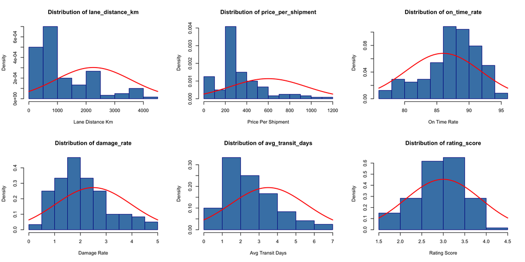

```r
par(mfrow = c(2,3))

for (col in names(carrier_num_features)){

  x <- carrier[[col]]

  hist(x,                                 # Creates density histograms of each numerical variable
       freq = FALSE,
       main = paste("Distribution of",col),
       xlab = str_to_title(gsub("_", " ", col)),
       border = 'darkblue', col = 'steelblue')

  curve(                                # Adds the normal distribution to each graph -
    dnorm(x, mean=mean(x), sd = sd(x)), # showing what a perfect normally distributed graph would
    col = "red", lwd = 2, add = TRUE)   # look like for that feature
}
```

- Lane distance (km): The distribution is strongly right-skewed, with most deliveries occurring on short to medium-distance lanes and a small number of very long-haul routes extending beyond 3,000 km. The overlaid normal curve highlights clear deviation from normality, driven by interstate and remote deliveries.
- Price per shipment: Prices show a right-skewed distribution, reflecting the influence of distance-based pricing and long-haul surcharges. Most shipments cluster at lower to mid-range prices, while a small number of long-distance deliveries create a heavy upper tail.
- On-time rate (%): On-time performance is approximately normally distributed, centered around the mid-to-high 80% range. The distribution is slightly truncated due to upper and lower bounds, which is expected given operational performance limits.
- Damage rate (%): Damage rates are moderately right-skewed, with most deliveries experiencing low damage incidence and fewer shipments showing elevated risk. The distribution aligns with realistic logistics outcomes where high damage rates are uncommon.
- Average transit days: Transit times display a right-skewed distribution, with most deliveries completed within two to three days and longer transit times associated with long-haul interstate routes. The skewness reflects distance and operational variability
- Rating score: Ratings form a truncated, near-normal distribution, concentrated around average-to-good scores. The bounded nature of the scale and its dependence on delivery performance and damage rates explain the limited spread at the extremes.

The distributions are realistic for a contract logistics setting, with expected right-skewness in distance, cost, and transit time, and stable performance-related metrics.

## 2.5 Distribution of categorical variables

Lastly, we visualise our categorical features using bar plots and frequency tables to examine the distribution of categorical variables. This step ensures that factor levels are balanced as intended and that no category dominates or appears unrealistically sparse.

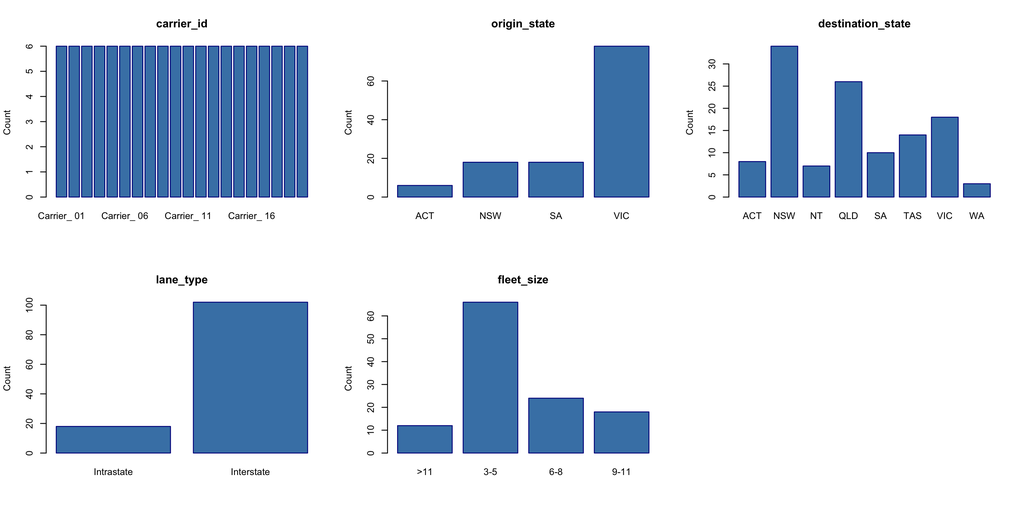

```r
# Filter all categorical features
carrier_categorical <- carrier |> select_if(is.factor)

# Again, display 2 x 3 graphs side-by-side
par(mfrow = c(2,3))

# For loop to create a barplot of each feature
for (col in names(carrier_categorical)){
  x <- carrier[[col]]

  barplot(height = table(x),
          main = col, ylab = "Count",
         col = "steelblue", border = "darkblue")
}
```

- Carrier: Our Observations are evenly distributed across all carriers, confirming balanced representation and ensuring that no single carrier dominates the data set.
- Origin state: Most shipments originate from VIC, reflecting the location of our central warehouse in Tullamarine. Other origin states such as NSW, SA, and ACT appear less frequently, consistent with the predefined sampling proportions.
- Destination state: Destination states are more broadly distributed, with higher shipment volumes to NSW and QLD, followed by VIC, SA, and TAS. WA and NT appear less frequently, reflecting fewer but longer long-haul routes.
- Lane type: Interstate lanes dominate the data set, indicating that the majority of shipments involve cross-state movements rather than intrastate deliveries within Victoria.
- Fleet size: Fleet sizes are concentrated in the `3-5` and `6-8` truck categories, suggesting a market dominated by small to medium-sized carriers. Larger fleet sizes are present but less common.

The categorical variables are balanced and operationally realistic distributions that align with the structure of a contract logistics network.

## 2.6 Distribution of our date feature - month

Lastly, let’s see the distribution of our month variable:

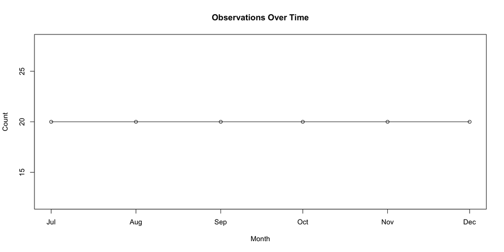

```r
# Lastly, we plot our month column
monthly_counts <- carrier |>
  count(month)

plot(
  x = monthly_counts$month,
  y = monthly_counts$n,
  type = "o",
  main = "Observations Over Time",
  xlab = "Month",
  ylab = "Count")
```

The number of observations is **uniform** across all months, with each month containing the same number of records. This confirms balanced temporal coverage in the data set and indicates that no month is over- or under-represented. As a result, comparisons across time are not biased by differences in data availability.

While our EDA focuses on data validation and understanding, the subsequent visual analysis focuses on answering business questions!

# 3. Visual Exploration and Insight Generation

Following the initial EDA, we will now move from validation to insight generation. In this stage:

- Visualisations are created to directly address the research question:
1. Compare carriers across cost, performance, reliability, speed, and service quality
2. Identify trade-offs between shipment price and operational performance (e.g. cost vs on-time delivery)
3. Understand the impact of operational factors such as lane distance, lane type, and fleet size on outcomes
4. Support evidence-based carrier selection and contract management decisions
5. Enable interactive exploration of carrier performance for operational and strategic stakeholders
- These visuals are then converted into **interactive** Plotly graphs, enabling:
1. Filtering by carrier, month, or lane type
2. Deeper comparison across carriers
3. Exploratory decision-making from a contract logistics perspective

These interactive visualisations form the foundation for the Shiny dashboard used to support data-driven carrier selection.

```r
# Take quick look of our data set
carrier |> head()
```

| carrier_id | month | origin_state | destination_state | lane_distance_km | lane_type | price_per_shipment | on_time_rate | damage_rate | avg_transit_days | fleet_size | rating_score |
| --- | --- | --- | --- | --- | --- | --- | --- | --- | --- | --- | --- |
| Carrier_ 01 | 2020-07-01 | VIC | NSW | 439 | Interstate | 177.66 | 85.23 | 1.7694 | 1.8 | 3-5 | 2.7 |
| Carrier_ 01 | 2020-08-01 | VIC | TAS | 625 | Interstate | 203.70 | 92.14 | 2.0633 | 1.4 | 3-5 | 3.5 |
| Carrier_ 01 | 2020-09-01 | VIC | ACT | 538 | Interstate | 191.52 | 89.60 | 1.2706 | 1.5 | 3-5 | 3.3 |
| Carrier_ 01 | 2020-10-01 | VIC | ACT | 501 | Interstate | 186.34 | 89.33 | 1.0863 | 1.6 | 3-5 | 3.3 |
| Carrier_ 01 | 2020-11-01 | VIC | QLD | 2164 | Interstate | 419.16 | 88.92 | 1.5542 | 3.3 | 3-5 | 4.2 |
| Carrier_ 01 | 2020-12-01 | VIC | QLD | 1865 | Interstate | 377.30 | 88.23 | 2.3065 | 3.8 | 3-5 | 2.9 |

## 3.1 How carriers compare on cost, performance, reliability, and service quality

3.1 will explore the key carrier benchmarks. We start by creating a price benchmark for each carrier:

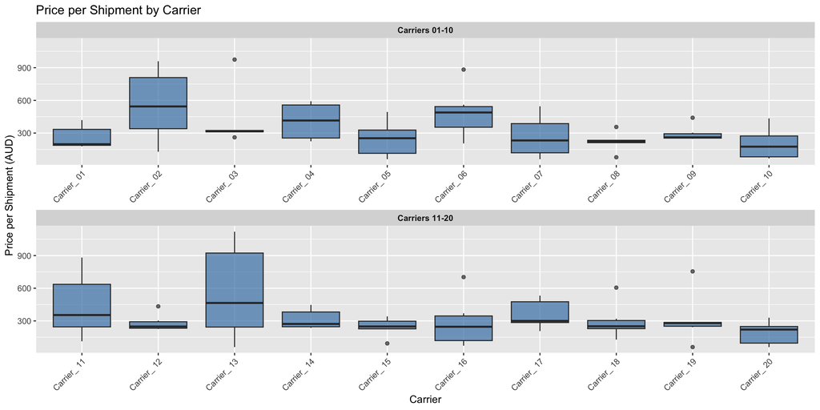

```r
# Price benchmark
## We group the carrier in half so we can explore all of them next to each other
carrier <- carrier |> mutate(
  carrier_group = if_else(
    as.numeric(str_extract(carrier_id, "\\d+")) <= 10,
    "Carriers 01-10",
    "Carriers 11-20"))

# Visualise the boxplots
ggplot(carrier, aes(x=carrier_id, y=price_per_shipment)) +
  geom_boxplot(fill = "steelblue", alpha = 0.7) +
  facet_wrap(~ carrier_group, ncol = 1, scales = "free_x") +
  labs(
    title = "Price per Shipment by Carrier",
    x = "Carrier",
    y = "Price per Shipment (AUD)"
  ) +
  theme(
    axis.text.x = element_text(angle = 45, hjust = 1),
    strip.text = element_text(face = "bold"))
```

## 3.2 Price vs. performance trade-offs

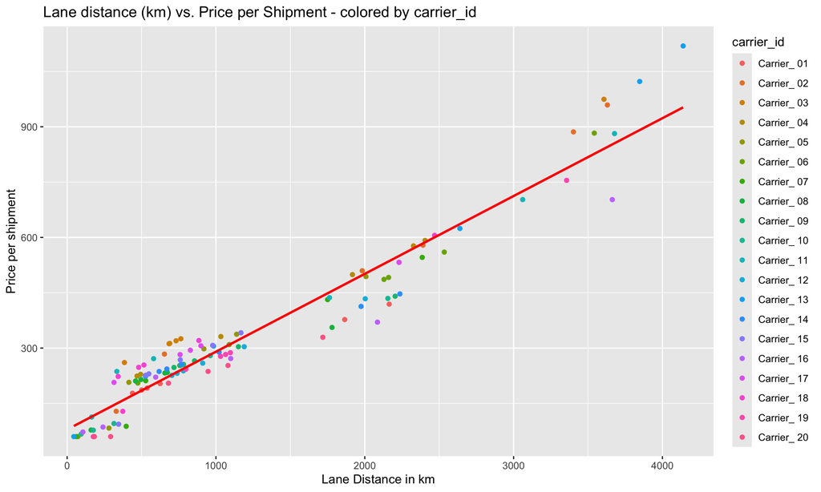

```r
ggplot(carrier, aes(x = lane_distance_km, y = price_per_shipment)) +
  geom_point(aes(color = carrier_id)) +
  geom_smooth(method = "lm", se = FALSE, col = 'red') +
  labs(
    title = "Lane distance (km) vs. Price per Shipment - colored by carrier_id",
    y = "Price per shipment",
    x = "Lane Distance in km"
  )
```